# Assignment 03 - Text Mining

Author

Mona Bandov

Published

November 3, 2023

## Assignment 03 - Text Mining

## **Due Date**

This assignment is due by midnight Pacific Time, November 3rd, 2023.

## **Text Mining**

A new dataset has been added to the data science data repository https://github.com/USCbiostats/data-science-data/tree/master/03_pubmed. The dataset contains 3,241 abstracts from articles collected via 5 PubMed searches. The search terms are listed in the second column, `term` and these will serve as the “documents.” Your job is to analyse these abstracts to find interesting insights.

Loading the packages and the CSV file.

```r
library(stringr)
library(readr)
library(tm)
library(tokenizers)
library(plyr)
library(tidytext)
library(tidyverse)
library(dplyr)
library(ggplot2)
library(forcats)
library(plyr)
library(magrittr)
pubmed <- read_csv("pubmed.csv")
head(pubmed)
```

```
# A tibble: 6 × 2
  abstract                                                                 term
  <chr>                                                                    <chr>
1 "Background and aims: Many patients with coronavirus disease 2019 (COVI… covid
2 "Introduction: Contradictory data have been reported on the incidence o… covid
3 "This article aims at collecting all information needed for dentists re… covid
4 "OBJECTIVE. The objective of our study was to determine the misdiagnosi… covid
5 "Background: Much of the focus regarding the global pandemic of coronav… covid
6 "The World Health Organization (WHO) has issued a warning that, althoug… covid
```

1. Tokenize the abstracts and count the number of each token. Do you see anything interesting? Does removing stop words change what tokens appear as the most frequent? What are the 5 most common tokens for each search term after removing stopwords?

```r
#Tokenize the abstracts and count the number of each token.
tokens <-unnest_tokens(pubmed, abstract, output = token, token = "words")
token_counts <-table(tokens$token)
top_tokens <- head(sort(token_counts, decreasing = TRUE), 5)
top_tokens
```

```
  the    of   and    in    to
28126 24760 19993 14653 10920
```

```r
#Does removing stop words change what tokens appear as the most frequent?
tokens <-unnest_tokens(pubmed, abstract, output = token, token = "words")
token_counts <- table(tokens$token)
stop_words <- stopwords("en")
tokens <- tokens[!tokens$token %in% stop_words, ]
filtered_token_counts <- table(tokens$token)
top_tokens <- head(sort(filtered_token_counts, decreasing = TRUE), 5)
top_tokens
```

```
   covid       19 patients   cancer prostate
    7275     7080     4674     3999     3832
```

2. Tokenize the abstracts into bigrams. Find the 10 most common bigrams and visualize them with ggplot2.

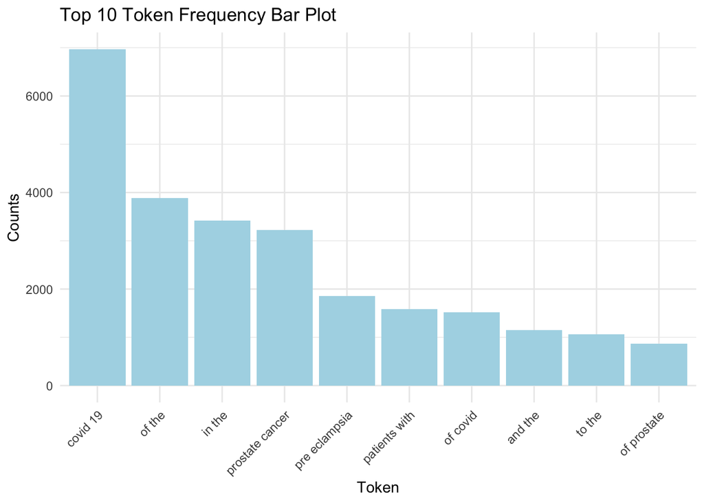

```r
tokens <-unnest_tokens(pubmed, abstract, output = token, token = "ngrams", n=2)
token_counts <-table(tokens$token)
top_tokens <- as.data.frame(head(sort(token_counts, decreasing = TRUE),10))

tokens_df <- as.data.frame(tokens)

filtered_tokens_df <- tokens_df %>%
  filter(token %in% top_tokens$Var1)


filtered_tokens_df$token <- factor(filtered_tokens_df$token, levels = top_tokens$Var1)

ggplot(filtered_tokens_df, aes(x = token)) +
  geom_bar(stat = "count", fill = "lightblue") +
  labs(x = "Token", y = "Counts") +
  ggtitle("Top 10 Token Frequency Bar Plot") +
  theme_minimal() +
  theme(axis.text.x = element_text(angle = 45, hjust = 1))
```

3. Calculate the TF-IDF value for each word-search term combination (here you want the search term to be the “document”). What are the 5 tokens from each search term with the highest TF-IDF value? How are the results different from the answers you got in question 1?

“TF gives weight to terms that appear a lot, IDF gives weight to terms that appears in a few documents.”

Instead of looking at each words as a whole, the table now separates the TD-IDF values by term. I noticed that based on the terms, the words are closely related to the topic of the term. This is because IDF ranks based on specificity and TF ranks on frequency. For example, term “Covid” has a high TD-IDF value for words such as “covid”, “pandemic”, “sars”, and “cov”. All of these values are words that are speicfic AND common in the term covid. Question 1 just counts the number of times a word occurs in the abstract.

```r
# calculating TI and IDF.
pubmed %>%
  unnest_tokens(word, abstract) %>%
  count(word, term) %>%
  bind_tf_idf(word, term, n) %>%
  arrange(term, desc(tf_idf)) %>%
  head(5)
```

```
# A tibble: 5 × 6
  word        term      n      tf   idf  tf_idf
  <chr>       <chr> <int>   <dbl> <dbl>   <dbl>
1 covid       covid  7275 0.0371   1.61 0.0597
2 pandemic    covid   800 0.00408  1.61 0.00657
3 coronavirus covid   647 0.00330  1.61 0.00531
4 sars        covid   372 0.00190  1.61 0.00305
5 cov         covid   334 0.00170  1.61 0.00274
```

```r
# 5 common
pubmed %>%
  unnest_tokens(word, abstract) %>%
  count(word, term) %>%
  bind_tf_idf(word, term, n) %>%
  arrange(term, desc(tf_idf)) %>%
  group_by(term) %>%
  slice_head(n=5)
```

```
# A tibble: 25 × 6
# Groups:   term [5]
   word        term                n      tf   idf  tf_idf
   <chr>       <chr>           <int>   <dbl> <dbl>   <dbl>
 1 covid       covid            7275 0.0371  1.61  0.0597
 2 pandemic    covid             800 0.00408 1.61  0.00657
 3 coronavirus covid             647 0.00330 1.61  0.00531
 4 sars        covid             372 0.00190 1.61  0.00305
 5 cov         covid             334 0.00170 1.61  0.00274
 6 cf          cystic fibrosis   625 0.0127  0.916 0.0117
 7 fibrosis    cystic fibrosis   867 0.0176  0.511 0.00901
 8 cystic      cystic fibrosis   862 0.0175  0.511 0.00896
 9 cftr        cystic fibrosis    86 0.00175 1.61  0.00282
10 sweat       cystic fibrosis    83 0.00169 1.61  0.00272
# ℹ 15 more rows
```